# Temperature shapes plant-pollinator interaction patterns independently of community composition

K.C. Arrowsmith, M.D. Strait, A. Schiffer, M. Chandar, and B.J. Brosi

# 1 Overview

This document contains all code necessary to replicate the analyses for the above article. Any questions about this project can be directed to Kaysee Arrowsmith at kcarrows@utexas.edu.

# 2 Setup

## 2.1 Load Packages

```r
library(knitr)
knitr::opts_chunk$set(echo = TRUE, message=FALSE, warning=FALSE)
library(tidyverse)
theme_set(theme_classic())
library(vegan)
library(ecodist)
library(mclogit)
library(glmmTMB)
library(DHARMa)
library(RColorBrewer)
library(geosphere)
library(Matrix)
library(lme4)
library(lmerTest)
library(ggeffects)
```

## 2.2 Matrix Regression Code

```r
MRM.base <- function (formula = formula(data), data, nperm = 1000, method = "linear", mrank = FALSE, permute.control = "permute.control") {
  m <- match.call(expand.dots = FALSE)
  m2 <- match(c("formula", "data"), names(m), nomatch = 0)
  m <- m[c(1, m2)]
  m[[1]] <- as.name("model.frame")
  m <- eval(m, parent.frame())
  m <- as.matrix(m)
  n <- (1 + sqrt(1 + 8 * nrow(m)))/2
  if (abs(n - round(n)) > 1e-07)
    stop("Matrix not square.\n")
  n <- round(n)
  if (ncol(m) < 2)
    stop("Not enough data. \n")
  if (method == "linear") {
    X <- m[, 2:ncol(m), drop = FALSE]
      Y <- m[, 1, drop = FALSE]
      colnames(Y) <- "Y"
      newdata <- data.frame(Y = Y, X)
      fit1 <- lm(Y ~ ., data = newdata)
      b <- coefficients(fit1)
      sig <- summary(fit1)$sigma
      sig.df <- summary(fit1)$df[2]
      b.pval <- NA
      dev.pval <- NA
      if (nperm > 0) {
        b.all <- matrix(NA, nrow = nperm, ncol = length(b))
        b.all[1, ] <- b
        sig.all <- rep(NA, nperm)
        sig.all[1] <- sig
        for (i in 2:nperm) {
          newSample <- shuffle(n, control = permute.control)
          newY <- full(Y)
          newY <- newY[newSample, newSample]
          newY <- lower(newY)
          newdata <- data.frame(Y = newY, X = X)
          newfit <- lm(Y ~ ., data = newdata)
          b.all[i, ] <- coefficients(newfit)
          sig.all[i] <- summary(newfit)$sigma
        }
        b.pval <- apply(b.all, 2, function(x) length(x[abs(x) >=
          abs(x[1])])/nperm)
        R2.pval <- length(sig.all[sig.all >= sig.all[1]])/nperm
      }
      results <- list(coef = cbind(b, pval = b.pval),
        R2 = c(R2 = sig, R2.df = sig.df,
          R2.pval = R2.pval))
  }
  else {
    if (method == "logistic") {
      X <- m[, 2:ncol(m), drop = FALSE]
      Y <- m[, 1, drop = FALSE]
      colnames(Y) <- "Y"
      newdata <- data.frame(Y = Y, X)
      fit1 <- glm(Y ~ ., data = newdata, family = binomial(link = "logit"))
      b <- coefficients(fit1)
      dev <- summary(fit1)$deviance
      dev.df <- summary(fit1)$df.residual
      b.pval <- NA
      dev.pval <- NA
      if (nperm > 0) {
        b.all <- matrix(NA, nrow = nperm, ncol = length(b))
        b.all[1, ] <- b
        dev.all <- rep(NA, nperm)
        dev.all[1] <- dev
        for (i in 2:nperm) {
          newSample <- shuffle(n, control = permute.control)
          newY <- full(Y)
          newY <- newY[newSample, newSample]
          newY <- lower(newY)
          newdata <- data.frame(Y = newY, X = X)
          newfit <- glm(Y ~ ., data = newdata, family = binomial(link = "logit"))
          b.all[i, ] <- coefficients(newfit)
          dev.all[i] <- summary(newfit)$deviance
        }
        b.pval <- apply(b.all, 2, function(x) length(x[abs(x) >=
          abs(x[1])])/nperm)
        dev.pval <- length(dev.all[dev.all >= dev.all[1]])/nperm
      }
      results <- list(coef = cbind(b, pval = b.pval),
        dev = c(resid.dev = dev, resid.df = dev.df,
          dev.pval = dev.pval))
    }
    else {
      stop("method must be 'linear' or 'logistic'\n")
    }
    }
  results
}
```

## 2.3 Load Data

```r
dat <- read.csv("data/tempint-networks.csv", stringsAsFactors = F) %>%
  mutate(date = as.Date(date, "%F"),
         year = format(date, "%Y"))
plants <- read.csv("data/tempint-plants.csv", stringsAsFactors = F) %>%
  mutate(date = as.Date(date, "%F"),
         year = format(date, "%Y"))
samptemps <- read.csv("data/tempint-samptemps.csv", stringsAsFactors = F) %>%
  mutate(date = as.Date(date, "%F"),
         year = format(date, "%Y")) %>%
  filter(!is.na(round),
         site %in% dat$site)
siteinfo <- read.csv("data/tempint-siteinfo.csv", stringsAsFactors = F)
```

# 3 Data Prep

## 3.1 Possible Interactions

Calculate every possible interaction that could have occurred based on the plants and pollinators observed at that date/site/round.

```r
# Family
poss.family <- dat %>%
  filter(insect_family != "") %>%
  group_by(date, site, round, insect_family) %>%
  tally() %>%
  full_join(plants, by = c("date", "site"), multiple = "all") %>%
  dplyr::select(date, site, round, insect_family, plant) %>%
  mutate(concat = as.factor(paste(date, site, round, sep = ".")),
         date.site = as.factor(paste(date, site, sep = ".")))

# Genus
poss.genus <- dat %>%
  filter(insect_genus != "") %>%
  group_by(date, site, round, insect_genus) %>%
  tally() %>%
  full_join(plants, by = c("date", "site"), multiple = "all") %>%
  dplyr::select(date, site, round, insect_genus, plant) %>%
    mutate(concat = as.factor(paste(date, site, round, sep = ".")),
         date.site = as.factor(paste(date, site, sep = ".")))

# Functional Group
poss.func <- dat %>%
  filter(gross_ID != "Unknown") %>%
  mutate_if(grepl("Bombus*", .), ~replace(., grepl("Bombus*", .), "Bombus")) %>%
  group_by(date, site, round, gross_ID) %>%
  tally() %>%
  full_join(plants, by = c("date", "site"), multiple = "all") %>%
  dplyr::select(date, site, round, gross_ID, plant) %>%
    mutate(concat = as.factor(paste(date, site, round, sep = ".")),
         date.site = as.factor(paste(date, site, sep = ".")))
```

## 3.2 Realized Interactions

Which of the possible interactions (above) actually occurred.

```r
# Family
occ.family <- dat %>%
  filter(insect_family != "") %>%
  group_by(date, site, round, insect_family, plant) %>%
  tally(name = "int") %>%
  right_join(poss.family, by = c("date", "site", "round", "insect_family", "plant")) %>%
  mutate(int = ifelse(is.na(int), 0, int))

# Genus
occ.genus <- dat %>%
  filter(insect_genus != "") %>%
  group_by(date, site, round, insect_genus, plant) %>%
  tally(name = "int") %>%
  right_join(poss.genus, by = c("date", "site", "round", "insect_genus", "plant")) %>%
  mutate(int = ifelse(is.na(int), 0, int))

# Functional Group
occ.func <- dat %>%
  filter(gross_ID != "Unknown") %>%
  mutate_if(grepl("Bombus*", .), ~replace(., grepl("Bombus*", .), "Bombus")) %>%
  group_by(date, site, round, gross_ID, plant) %>%
  tally(name = "int") %>%
  right_join(poss.func, by = c("date", "site", "round", "gross_ID", "plant")) %>%
  mutate(int = ifelse(is.na(int), 0, int))
```

## 3.3 Join Temperature

Attach the temperature for each sampling round. We also calculate some relative abundances here that will be useful for plotting our results later on.

```r
# Family
final.family <- occ.family %>%
  left_join(samptemps, by = c("date", "site", "round")) %>%
  mutate(int.ID = paste(insect_family, plant, sep = ".")) %>%
  dplyr::select(date, site, round, date.site, concat, insect_family, plant, int.ID, int, avg.temp) #, latitude, longitude)

# Genus
final.genus <- occ.genus %>%
  left_join(samptemps, by = c("date", "site", "round")) %>%
  mutate(int.ID = paste(insect_genus, plant, sep = "."),
         year = format(date, "%Y")) %>%
         # midtime = as.numeric(strptime(starttime, format = "%H:%M")) + as.numeric(strptime(endtime, format = "%H:%M"))/2,
         # doy = format(date, "%j")) %>%
  dplyr::select(date, year, site, round, date.site, concat, insect_genus, plant, int.ID, int, avg.temp)#, latitude, longitude, midtime, doy)

final.func <- occ.func %>%
  left_join(samptemps, by = c("date", "site", "round")) %>%
  mutate(int.ID = paste(gross_ID, plant, sep = "."),
         year = format(date, "%Y")) %>%
         # midtime = as.numeric(strptime(starttime, format = "%H:%M")) + as.numeric(strptime(endtime, format = "%H:%M"))/2,
         # doy = format(date, "%j")) %>%
  dplyr::select(date, year, site, round, date.site, concat, gross_ID, plant, int.ID, int, avg.temp)#, latitude, longitude, midtime, doy)
```

# 4 Analysis

## 4.1 Relationship between Temperature and Round

This checks whether temperature varied with round. *A priori*, we would assume that temperature varies with date, but that should not matter in our analysis since our choice sets are always within a single date. However, we include date here too in order to control for that effect.

```r
round.mod <- lmer(avg.temp ~ date + as.factor(round) + (1|site), data = samptemps)
summary(round.mod)
```

```
## Linear mixed model fit by REML. t-tests use Satterthwaite's method [
## lmerModLmerTest]
## Formula: avg.temp ~ date + as.factor(round) + (1 | site)
##    Data: samptemps
##
## REML criterion at convergence: 1156.9
##
## Scaled residuals:
##      Min       1Q   Median       3Q      Max
## -2.66524 -0.58990 -0.04593  0.65944  2.33962
##
## Random effects:
##  Groups   Name        Variance Std.Dev.
##  site     (Intercept)  2.275   1.508
##  Residual             16.298   4.037
## Number of obs: 203, groups:  site, 6
##
## Fixed effects:
##                     Estimate Std. Error         df t value Pr(>|t|)
## (Intercept)       101.689518  31.697145 197.176783   3.208  0.00156 **
## date               -0.004049   0.001663 197.414224  -2.436  0.01576 *
## as.factor(round)2   2.597828   0.680227 194.334156   3.819  0.00018 ***
## as.factor(round)3   3.253508   0.704645 194.432966   4.617 7.06e-06 ***
## ---
## Signif. codes:  0 '***' 0.001 '**' 0.01 '*' 0.05 '.' 0.1 ' ' 1
##
## Correlation of Fixed Effects:
##             (Intr) date   as.()2
## date        -1.000
## as.fctr(r)2 -0.015  0.005
## as.fctr(r)3 -0.022  0.012  0.487
```

```r
anova(round.mod)
```

```
## Type III Analysis of Variance Table with Satterthwaite's method
##                  Sum Sq Mean Sq NumDF  DenDF F value    Pr(>F)
## date              96.68  96.684     1 197.41  5.9321   0.01576 *
## as.factor(round) 400.27 200.134     2 194.37 12.2795 9.508e-06 ***
## ---
## Signif. codes:  0 '***' 0.001 '**' 0.01 '*' 0.05 '.' 0.1 ' ' 1
```

```r
samptemps.BC21 <- samptemps %>% filter(site == "Brush Creek Hill", year == "2021")
test.bc21 <- aov(avg.temp ~ round, data = samptemps.BC21)
summary(test.bc21)
```

```
##             Df Sum Sq Mean Sq F value Pr(>F)
## round        1   2.66   2.658    0.16  0.695
## Residuals   15 249.31  16.621
```

```r
samptemps.BC22 <- samptemps %>% filter(site == "Brush Creek Hill", year == "2022")
test.bc22 <- aov(avg.temp ~ round, data = samptemps.BC22)
summary(test.bc22)
```

```
##             Df Sum Sq Mean Sq F value Pr(>F)
## round        1   61.8   61.82   2.525  0.132
## Residuals   16  391.7   24.48
```

```r
samptemps.KP21 <- samptemps %>% filter(site == "Kebler Pass", year == "2021")
test.kp21 <- aov(avg.temp ~ round, data = samptemps.KP21)
summary(test.kp21)
```

```
##             Df Sum Sq Mean Sq F value Pr(>F)
## round        1  72.52   72.52   4.231 0.0545 .
## Residuals   18 308.48   17.14
## ---
## Signif. codes:  0 '***' 0.001 '**' 0.01 '*' 0.05 '.' 0.1 ' ' 1
```

```r
samptemps.KP22 <- samptemps %>% filter(site == "Kebler Pass", year == "2022")
test.kp22 <- aov(avg.temp ~ round, data = samptemps.KP22)
summary(test.kp22)
```

```
##             Df Sum Sq Mean Sq F value Pr(>F)
## round        1   96.7   96.73   2.886  0.107
## Residuals   18  603.3   33.51
```

```r
samptemps.OPH22 <- samptemps %>% filter(site == "Ohio Pass High", year == "2022")
test.oph22 <- aov(avg.temp ~ round, data = samptemps.OPH22)
summary(test.oph22)
```

```
##             Df Sum Sq Mean Sq F value  Pr(>F)
## round        1  65.99   65.99   9.254 0.00701 **
## Residuals   18 128.35    7.13
## ---
## Signif. codes:  0 '***' 0.001 '**' 0.01 '*' 0.05 '.' 0.1 ' ' 1
```

```r
samptemps.OPL22 <- samptemps %>% filter(site == "Ohio Pass Low", year == "2022")
test.opl22 <- aov(avg.temp ~ round, data = samptemps.OPL22)
summary(test.opl22)
```

```
##             Df Sum Sq Mean Sq F value  Pr(>F)
## round        1  161.8   161.8   12.74 0.00205 **
## Residuals   19  241.4    12.7
## ---
## Signif. codes:  0 '***' 0.001 '**' 0.01 '*' 0.05 '.' 0.1 ' ' 1
```

```r
samptemps.RG21 <- samptemps %>% filter(site == "Rustlers Gulch", year == "2021")
test.rg21 <- aov(avg.temp ~ round, data = samptemps.RG21)
summary(test.rg21)
```

```
##             Df Sum Sq Mean Sq F value Pr(>F)
## round        1   5.51   5.512   0.691  0.416
## Residuals   19 151.55   7.976
```

```r
samptemps.RG22 <- samptemps %>% filter(site == "Rustlers Gulch", year == "2022")
test.rg22 <- aov(avg.temp ~ round, data = samptemps.RG22)
summary(test.rg22)
```

```
##             Df Sum Sq Mean Sq F value Pr(>F)
## round        1  24.04  24.035   3.886  0.062 .
## Residuals   21 129.90   6.186
## ---
## Signif. codes:  0 '***' 0.001 '**' 0.01 '*' 0.05 '.' 0.1 ' ' 1
```

```r
samptemps.SF21 <- samptemps %>% filter(site == "Stupid Falls", year == "2021")
test.sf21 <- aov(avg.temp ~ round, data = samptemps.SF21)
summary(test.sf21)
```

```
##             Df Sum Sq Mean Sq F value Pr(>F)
## round        1   7.55   7.552   0.484  0.495
## Residuals   18 280.57  15.587
```

```r
samptemps.SF22 <- samptemps %>% filter(site == "Stupid Falls", year == "2022")
test.sf22 <- aov(avg.temp ~ round, data = samptemps.SF22)
summary(test.sf22)
```

```
##             Df Sum Sq Mean Sq F value Pr(>F)
## round        1   1.88   1.879   0.128  0.724
## Residuals   21 307.73  14.654
```

Round does significantly impact temperature, so it will make sense to include round as a main effect in our subsequent analyses.

## 4.2 Multinomial Choice

### 4.2.1 Functional Groups

First, we run this analysis with insects grouped by functional group. This comprises the largest amount of data.

```r
mc.func <- mclogit(cbind(int, as.integer(date.site)) ~
                     poly(avg.temp, 2, raw = TRUE) +
                      round,
                   random = list(~1 + avg.temp|gross_ID,
                                 ~1 + avg.temp|plant),
                   data = final.func)
```

```
##
## Iteration 1 - deviance = 7642.989 - criterion = 0.9750322
## Iteration 2 - deviance = 7406.953 - criterion = 0.02171564
## Iteration 3 - deviance = 7372.524 - criterion = 0.006595092
## Iteration 4 - deviance = 7359.378 - criterion = 0.002509788
## Iteration 5 - deviance = 7355.008 - criterion = 0.0004060375
## Iteration 6 - deviance = 7353.892 - criterion = 1.42128e-05
## Iteration 7 - deviance = 7353.768 - criterion = 1.665352e-08
## Iteration 8 - deviance = 7353.765 - criterion = 2.241216e-14
```

```r
summary(mc.func)
```

```
##
## Call:
## mclogit(formula = cbind(int, as.integer(date.site)) ~ poly(avg.temp,
##     2, raw = TRUE) + round, data = final.func, random = list(~1 +
##     avg.temp | gross_ID, ~1 + avg.temp | plant))
##
## Coefficents:
##                                 Estimate Std. Error z value Pr(>|z|)
## poly(avg.temp, 2, raw = TRUE)1  0.223761   0.073300   3.053  0.00227 **
## poly(avg.temp, 2, raw = TRUE)2 -0.005100   0.001249  -4.082 4.46e-05 ***
## round                          -0.109061   0.034086  -3.200  0.00138 **
## ---
## Signif. codes:  0 '***' 0.001 '**' 0.01 '*' 0.05 '.' 0.1 ' ' 1
##
## (Co-)Variances:
## Grouping level: gross_ID
##          Estimate            Std.Err.
## (Const.) 3.799648            3.1169084
## avg.temp 0.027094 0.005037   0.0222519 0.0001588
##
## Grouping level: plant
##          Estimate            Std.Err.
## (Const.) 2.278452            1.2228391
## avg.temp 0.053256 0.005564   0.0286361 0.0006706
##
## Approximate residual deviance: 7354
## Number of Fisher scoring iterations:  8
## Number of observations
##   Groups by gross_ID: 15
##   Groups by plant: 64
##   Individual observations:  2585
```

### 4.2.2 Family

Next, we run this analysis with insects identified to the family level. This is a coarser-scale analysis than genus level, but there are a larger number of data points at the family level (because it includes insects for which we can identify to family but not to genus).

```r
mc.family <- mclogit(cbind(int, as.integer(date.site)) ~
                     poly(avg.temp, 2, raw = TRUE) +
                       round,
                   random = list(~1 + avg.temp|insect_family,
                                 ~1 + avg.temp|plant),
                   data = final.family)
```

```
##
## Iteration 1 - deviance = 6491.926 - criterion = 0.9728174
## Iteration 2 - deviance = 6263.399 - criterion = 0.09454671
## Iteration 3 - deviance = 6230.284 - criterion = 0.00999848
## Iteration 4 - deviance = 6217.646 - criterion = 0.003267884
## Iteration 5 - deviance = 6213.545 - criterion = 0.000471417
## Iteration 6 - deviance = 6212.608 - criterion = 1.337051e-05
## Iteration 7 - deviance = 6212.513 - criterion = 9.443067e-09
```

```r
summary(mc.family)
```

```
##
## Call:
## mclogit(formula = cbind(int, as.integer(date.site)) ~ poly(avg.temp,
##     2, raw = TRUE) + round, data = final.family, random = list(~1 +
##     avg.temp | insect_family, ~1 + avg.temp | plant))
##
## Coefficents:
##                                 Estimate Std. Error z value Pr(>|z|)
## poly(avg.temp, 2, raw = TRUE)1  0.170325   0.078643   2.166  0.03033 *
## poly(avg.temp, 2, raw = TRUE)2 -0.004460   0.001376  -3.241  0.00119 **
## round                          -0.077686   0.038856  -1.999  0.04557 *
## ---
## Signif. codes:  0 '***' 0.001 '**' 0.01 '*' 0.05 '.' 0.1 ' ' 1
##
## (Co-)Variances:
## Grouping level: insect_family
##          Estimate            Std.Err.
## (Const.) 1.859016            1.876561
## avg.temp 0.044042 0.005766   0.044570 0.001059
##
## Grouping level: plant
##          Estimate            Std.Err.
## (Const.) 2.010024            1.2153087
## avg.temp 0.049912 0.005159   0.0302364 0.0007523
##
## Approximate residual deviance: 6213
## Number of Fisher scoring iterations:  7
## Number of observations
##   Groups by insect_family: 37
##   Groups by plant: 64
##   Individual observations:  2124
```

### 4.2.3 Genus

Next, we run this analysis again but at the genus level. This is a finer-scale analysis that eliminates some uncertainty associated with the potential for variation among genera within the same family, but it loses some statistical power since we have roughly 500 fewer interactions that can be identified to the genus level.

```r
mc.genus <- mclogit(cbind(int, as.integer(date.site)) ~
                     poly(avg.temp, 2, raw = TRUE) +
                      round,
                   random = list(~1 + avg.temp|insect_genus,
                                 ~1 + avg.temp|plant),
                   data = final.genus)
```

```
##
## Iteration 1 - deviance = 5189.292 - criterion = 0.9178357
## Iteration 2 - deviance = 5086.866 - criterion = 0.02430653
## Iteration 3 - deviance = 5058.967 - criterion = 0.003680271
## Iteration 4 - deviance = 5029.556 - criterion = 0.001792912
## Iteration 5 - deviance = 5000.943 - criterion = 0.001973756
## Iteration 6 - deviance = 4974.1 - criterion = 0.001997291
## Iteration 7 - deviance = 4950.184 - criterion = 0.001860424
## Iteration 8 - deviance = 4929.955 - criterion = 0.001618803
## Iteration 9 - deviance = 4913.621 - criterion = 0.001343169
## Iteration 10 - deviance = 4900.911 - criterion = 0.001084788
## Iteration 11 - deviance = 4891.257 - criterion = 0.0008686005
## Iteration 12 - deviance = 4884.002 - criterion = 0.0007008919
## Iteration 13 - deviance = 4878.535 - criterion = 0.0005777871
## Iteration 14 - deviance = 4874.354 - criterion = 0.0004907416
## Iteration 15 - deviance = 4871.082 - criterion = 0.0004296845
## Iteration 16 - deviance = 4868.451 - criterion = 0.0003847052
## Iteration 17 - deviance = 4866.282 - criterion = 0.0003468096
## Iteration 18 - deviance = 4864.461 - criterion = 0.0003081801
## Iteration 19 - deviance = 4862.92 - criterion = 0.0002624472
## Iteration 20 - deviance = 4861.631 - criterion = 0.0002056703
## Iteration 21 - deviance = 4860.59 - criterion = 0.0001392979
## Iteration 22 - deviance = 4859.925 - criterion = 5.395226e-05
## Iteration 23 - deviance = 4859.545 - criterion = 2.051158e-05
## Iteration 24 - deviance = 4859.299 - criterion = 2.425215e-05
## Iteration 25 - deviance = 4859.164 - criterion = 3.435256e-05
```

```r
summary(mc.genus)
```

```
##
## Call:
## mclogit(formula = cbind(int, as.integer(date.site)) ~ poly(avg.temp,
##     2, raw = TRUE) + round, data = final.genus, random = list(~1 +
##     avg.temp | insect_genus, ~1 + avg.temp | plant))
##
## Coefficents:
##                                 Estimate Std. Error z value Pr(>|z|)
## poly(avg.temp, 2, raw = TRUE)1  0.162469   0.092899   1.749   0.0803 .
## poly(avg.temp, 2, raw = TRUE)2 -0.004019   0.001651  -2.435   0.0149 *
## round                          -0.029829   0.043986  -0.678   0.4977
## ---
## Signif. codes:  0 '***' 0.001 '**' 0.01 '*' 0.05 '.' 0.1 ' ' 1
##
## (Co-)Variances:
## Grouping level: insect_genus
##          Estimate                Std.Err.
## (Const.)  3.026e-02              3.860e-06
## avg.temp -1.238e-03  9.927e-05   1.582e-07 6.481e-09
##
## Grouping level: plant
##          Estimate            Std.Err.
## (Const.)  4.41538            1.0734239
## avg.temp -0.08288  0.00359   0.0201589 0.0003786
##
## Approximate residual deviance: 4859
## Number of Fisher scoring iterations:  25
## Number of observations
##   Groups by insect_genus: 52
##   Groups by plant: 64
##   Individual observations:  1627
## Note: Algorithm did not converge.
```

Since we found similar results at both the family and genus levels, we perform all subsequent analyses at the genus level to take advantage of the finer taxonomic resolution.

## 4.3 Relationship between Temperature and Pollinator Community

### 4.3.1 Abundance

We will check whether temperature affects the number of pollinators actively foraging during our sampling periods.

```r
func.active <- final.func %>%
  mutate(round = as.factor(round)) %>%
  group_by(date, site, round, avg.temp, gross_ID) %>%
  summarise(num.active = sum(int))

total.func <- func.active %>%
  group_by(date, site, round) %>%
  summarise(total.active = sum(num.active))

func.subset <- func.active %>%
  group_by(date, site, gross_ID) %>%
  tally() %>%
  filter(n == 3) %>%
  inner_join(func.active, by = c("date", "site", "gross_ID")) %>%
  dplyr::select(-n) %>%
  left_join(total.func, by = c("date", "site", "round"))

activity.func <- glmmTMB(cbind(num.active, total.active-num.active) ~ poly(avg.temp, 2, raw = TRUE) + round + (1|date) + (1|site) + (1 + avg.temp|gross_ID),
                          data = func.subset,
                         family = binomial)
summary(activity.func)
```

```
##  Family: binomial  ( logit )
## Formula:
## cbind(num.active, total.active - num.active) ~ poly(avg.temp,
##     2, raw = TRUE) + round + (1 | date) + (1 | site) + (1 + avg.temp |
##     gross_ID)
## Data: func.subset
##
##      AIC      BIC   logLik deviance df.resid
##   1888.6   1927.6   -934.3   1868.6      353
##
## Random effects:
##
## Conditional model:
##  Groups   Name        Variance  Std.Dev.  Corr
##  date     (Intercept) 1.090e-01 3.302e-01
##  site     (Intercept) 3.265e-09 5.714e-05
##  gross_ID (Intercept) 4.904e+00 2.215e+00
##           avg.temp    4.341e-03 6.589e-02 -0.95
## Number of obs: 363, groups:  date, 46; site, 6; gross_ID, 7
##
## Conditional model:
##                                  Estimate Std. Error z value Pr(>|z|)
## (Intercept)                    -0.9604050  1.6569274  -0.580    0.562
## poly(avg.temp, 2, raw = TRUE)1 -0.0229519  0.1025394  -0.224    0.823
## poly(avg.temp, 2, raw = TRUE)2  0.0005544  0.0017317   0.320    0.749
## round2                         -0.0753297  0.0815248  -0.924    0.355
## round3                         -0.0773739  0.0887164  -0.872    0.383
```

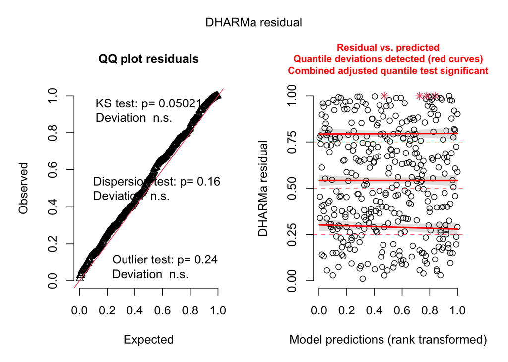

```r
actfunc.resid <- simulateResiduals(activity.func, n = 250)
plot(actfunc.resid)
```

```r
family.active <- final.family %>%
  mutate(round = as.factor(round)) %>%
  group_by(date, site, round, avg.temp, insect_family) %>%
  summarise(num.active = sum(int))

total.family <- family.active %>%
  group_by(date, site, round) %>%
  summarise(total.active = sum(num.active))

family.subset <- family.active %>%
  group_by(date, site, insect_family) %>%
  tally() %>%
  filter(n == 3) %>%
  inner_join(family.active, by = c("date", "site", "insect_family")) %>%
  dplyr::select(-n) %>%
  left_join(total.family, by = c("date", "site", "round"))

activity.family <- glmmTMB(cbind(num.active, total.active-num.active) ~ poly(avg.temp, 2, raw = TRUE) + round + (1|date) + (1|site) + (1 + avg.temp|insect_family),
                          data = family.subset,
                         family = binomial)

summary(activity.family)
```

```
##  Family: binomial  ( logit )
## Formula:
## cbind(num.active, total.active - num.active) ~ poly(avg.temp,
##     2, raw = TRUE) + round + (1 | date) + (1 | site) + (1 + avg.temp |
##     insect_family)
## Data: family.subset
##
##      AIC      BIC   logLik deviance df.resid
##   1176.5   1211.6   -578.3   1156.5      236
##
## Random effects:
##
## Conditional model:
##  Groups        Name        Variance  Std.Dev.  Corr
##  date          (Intercept) 2.168e-01 4.657e-01
##  site          (Intercept) 3.246e-09 5.698e-05
##  insect_family (Intercept) 7.700e+00 2.775e+00
##                avg.temp    1.149e-02 1.072e-01 -0.98
## Number of obs: 246, groups:  date, 40; site, 6; insect_family, 14
##
## Conditional model:
##                                  Estimate Std. Error z value Pr(>|z|)
## (Intercept)                    -0.3495175  2.1520437  -0.162    0.871
## poly(avg.temp, 2, raw = TRUE)1 -0.0362095  0.1420572  -0.255    0.799
## poly(avg.temp, 2, raw = TRUE)2  0.0002365  0.0024072   0.098    0.922
## round2                         -0.1470876  0.1092397  -1.346    0.178
## round3                          0.0963853  0.1209730   0.797    0.426
```

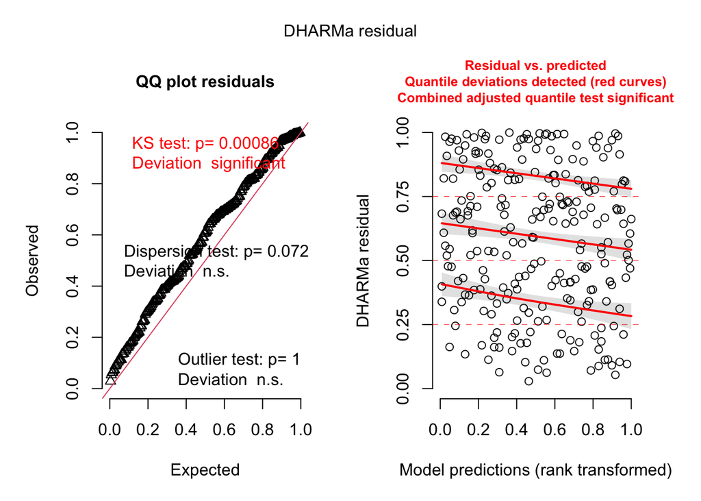

```r
actfam.resid <- simulateResiduals(activity.family, n = 250)
plot(actfam.resid)
```

```r
genus.active <- final.genus %>%
  mutate(round = as.factor(round)) %>%
  group_by(date, site, round, avg.temp, insect_genus) %>%
  summarise(num.active = sum(int))

total.genus <- genus.active %>%
  group_by(date, site, round) %>%
  summarise(total.active = sum(num.active))

genus.subset <- genus.active %>%
  group_by(date, site, insect_genus) %>%
  tally() %>%
  filter(n == 3) %>%
  inner_join(genus.active, by = c("date", "site", "insect_genus")) %>%
  dplyr::select(-n) %>%
  left_join(total.genus, by = c("date", "site", "round"))

activity.genus <- glmmTMB(cbind(num.active, total.active-num.active) ~ poly(avg.temp, 2, raw = TRUE) + round + (1|date) + (1|site) + (1 + avg.temp|insect_genus),
                          data = genus.subset,
                         family = binomial)
summary(activity.genus)
```

```
##  Family: binomial  ( logit )
## Formula:
## cbind(num.active, total.active - num.active) ~ poly(avg.temp,
##     2, raw = TRUE) + round + (1 | date) + (1 | site) + (1 + avg.temp |
##     insect_genus)
## Data: genus.subset
##
##      AIC      BIC   logLik deviance df.resid
##    721.1    751.6   -350.5    701.1      146
##
## Random effects:
##
## Conditional model:
##  Groups       Name        Variance Std.Dev. Corr
##  date         (Intercept)  0.67368 0.8208
##  site         (Intercept)  0.14004 0.3742
##  insect_genus (Intercept) 19.01941 4.3611
##               avg.temp     0.02255 0.1502   -0.97
## Number of obs: 156, groups:  date, 33; site, 6; insect_genus, 12
##
## Conditional model:
##                                 Estimate Std. Error z value Pr(>|z|)
## (Intercept)                     3.229362   3.385593   0.954    0.340
## poly(avg.temp, 2, raw = TRUE)1 -0.304036   0.223456  -1.361    0.174
## poly(avg.temp, 2, raw = TRUE)2  0.005317   0.003841   1.384    0.166
## round2                         -0.049612   0.164785  -0.301    0.763
## round3                          0.230728   0.190392   1.212    0.226
```

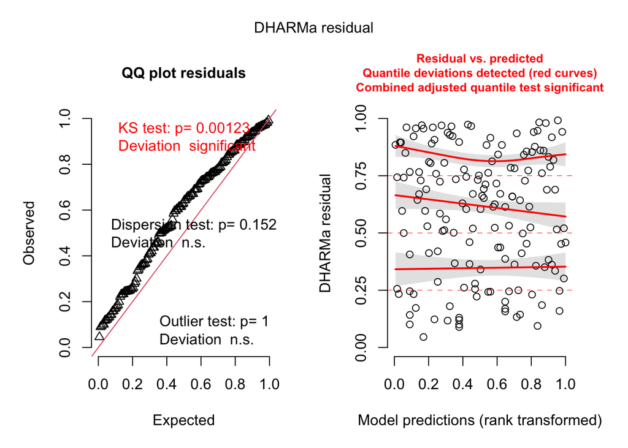

```r
actgen.resid <- simulateResiduals(activity.genus, n = 250)
plot(actgen.resid)
```

No significance of any fixed effects at the genus level. As with the family-level diagnostics, we see significance in the KS test consistent with overdispersion. The genus-level analysis will converge with a betabinomial distribution but lack of significance remains the same.

### 4.3.2 Composition

Next, we will use matrix regression to examine how dissimilarity in community composition relates to dissimilarity in temperature. For this analysis, we will include site/year and round as controlling factors that limit how permutations are conducted. We do not include round as a fixed effect because the MRM does not work with categorical variables.

```r
plants.sum <-  plants %>%
  filter(plant != "") %>%
  mutate(site.date = paste(site, date, sep = ".")) %>%
  group_by(site.date, plant) %>%
  summarise(total_flowers = sum(total_flowers))

func.polmatrix <- final.func %>%
  group_by(concat, gross_ID) %>%
  summarise(num.active = sum(int)) %>%
  pivot_wider(names_from = gross_ID,
              values_from = num.active,
              values_fill = 0) %>%
  arrange(concat) %>%
  column_to_rownames(var = "concat")

func.polbeta <- as.matrix(vegdist(func.polmatrix, method = "horn"))

func.explanatory <- data.frame(concat = rownames(func.polmatrix)) %>%
  separate(concat, into = c("date", "site", "round"), sep = "[.]", remove = F) %>%
  mutate(date = as.Date(date),
         round = as.numeric(round),
         site.date = paste(site, date, sep = ".")) %>%
  left_join(samptemps, by = c("date", "site", "round")) %>%
  mutate(doy = strftime(date, format = "%j"),
         year = strftime(date, format = "%Y")) %>%
  arrange(concat)

func.tempdiff <- as.matrix(dist(func.explanatory$avg.temp))
rownames(func.tempdiff) <- rownames(func.polmatrix)
colnames(func.tempdiff) <- rownames(func.polmatrix)

func.doydiff <- as.matrix(dist(func.explanatory$doy))
rownames(func.doydiff) <- rownames(func.polmatrix)
colnames(func.doydiff) <- rownames(func.polmatrix)

func.rounddiff <- as.matrix(dist(func.explanatory$round))
rownames(func.rounddiff) <- rownames(func.polmatrix)
colnames(func.rounddiff) <- rownames(func.polmatrix)

func.plantmatrix <- func.explanatory %>%
  dplyr::select(site.date, concat) %>%
  left_join(plants.sum, by = "site.date") %>%
  dplyr::select(!site.date) %>%
  pivot_wider(names_from = plant,
              values_from = total_flowers,
              values_fill = 0) %>%
  arrange(concat) %>%
  column_to_rownames(var = "concat")

func.plantbeta <- as.matrix(vegdist(func.plantmatrix, method = "horn"))

## Permutation Controls
func.concatdf <- data.frame(row = 1:nrow(func.polmatrix),
                        concat = rownames(func.polmatrix)) %>%
  separate_wider_delim(cols = concat, names = c("date", "site", "round"), delim = ".") %>%
  mutate(year = strftime(date, format = "%Y"),
         site.year = paste(site, year, sep = "."))

func.control <- how(Within(type = "free"),
                     plots = Plots(as.factor(func.concatdf$site.year)),
                     blocks = as.factor(func.concatdf$round))

## MRM
set.seed(15723)
func.mrm <- suppressWarnings(MRM.base(as.dist(func.polbeta) ~
                  as.dist(func.tempdiff) +
                  as.dist(func.plantbeta) +
                  as.dist(func.doydiff),
                method = "logistic",
                nperm = 1000,
                permute.control = func.control))
func.mrm
```

```
## $coef
##                                    b  pval
## (Intercept)             -0.324750229 0.001
## as.dist.func.tempdiff.   0.017162610 0.096
## as.dist.func.plantbeta.  0.557472037 0.031
## as.dist.func.doydiff.    0.008174757 0.001
##
## $dev
## resid.dev  resid.df  dev.pval
##  7494.812 20096.000     1.000
```

```r
family.polmatrix <- final.family %>%
  group_by(concat, insect_family) %>%
  summarise(num.active = sum(int)) %>%
  pivot_wider(names_from = insect_family,
              values_from = num.active,
              values_fill = 0) %>%
  arrange(concat) %>%
  column_to_rownames(var = "concat")

family.polbeta <- as.matrix(vegdist(family.polmatrix, method = "horn"))

family.explanatory <- data.frame(concat = rownames(family.polmatrix)) %>%
  separate(concat, into = c("date", "site", "round"), sep = "[.]", remove = F) %>%
  mutate(date = as.Date(date),
         round = as.numeric(round),
         site.date = paste(site, date, sep = ".")) %>%
  left_join(samptemps, by = c("date", "site", "round")) %>%
  mutate(doy = strftime(date, format = "%j"),
         year = strftime(date, format = "%Y")) %>%
  arrange(concat)

family.tempdiff <- as.matrix(dist(family.explanatory$avg.temp))
rownames(family.tempdiff) <- rownames(family.polmatrix)
colnames(family.tempdiff) <- rownames(family.polmatrix)

family.doydiff <- as.matrix(dist(family.explanatory$doy))
rownames(family.doydiff) <- rownames(family.polmatrix)
colnames(family.doydiff) <- rownames(family.polmatrix)

family.rounddiff <- as.matrix(dist(family.explanatory$round))
rownames(family.rounddiff) <- rownames(family.polmatrix)
colnames(family.rounddiff) <- rownames(family.polmatrix)

family.plantmatrix <- family.explanatory %>%
  dplyr::select(site.date, concat) %>%
  left_join(plants.sum, by = "site.date") %>%
  dplyr::select(!site.date) %>%
  pivot_wider(names_from = plant,
              values_from = total_flowers,
              values_fill = 0) %>%
  arrange(concat) %>%
  column_to_rownames(var = "concat")

family.plantbeta <- as.matrix(vegdist(family.plantmatrix, method = "horn"))

## Permutation Controls
family.concatdf <- data.frame(row = 1:nrow(family.polmatrix),
                        concat = rownames(family.polmatrix)) %>%
  separate_wider_delim(cols = concat, names = c("date", "site", "round"), delim = ".") %>%
  mutate(year = strftime(date, format = "%Y"),
         site.year = paste(site, year, sep = "."))

family.control <- how(Within(type = "free"),
                     plots = Plots(as.factor(family.concatdf$site.year)),
                     blocks = as.factor(family.concatdf$round))

## MRM
set.seed(71523)
family.mrm <- suppressWarnings(MRM.base(as.dist(family.polbeta) ~
                  as.dist(family.tempdiff) +
                  as.dist(family.plantbeta) +
                  as.dist(family.doydiff),
                method = "logistic",
                nperm = 1000,
                permute.control = family.control))
family.mrm
```

```
## $coef
##                                     b  pval
## (Intercept)               0.097492788 1.000
## as.dist.family.tempdiff.  0.013756718 0.275
## as.dist.family.plantbeta. 0.506663633 0.034
## as.dist.family.doydiff.   0.008344169 0.001
##
## $dev
## resid.dev  resid.df  dev.pval
##  9335.089 19896.000     1.000
```

```r
genus.polmatrix <- final.genus %>%
  group_by(concat, insect_genus) %>%
  summarise(num.active = sum(int)) %>%
  pivot_wider(names_from = insect_genus,
              values_from = num.active,
              values_fill = 0) %>%
  arrange(concat) %>%
  column_to_rownames(var = "concat")

genus.polbeta <- as.matrix(vegdist(genus.polmatrix, method = "horn"))

genus.explanatory <- data.frame(concat = rownames(genus.polmatrix)) %>%
  separate(concat, into = c("date", "site", "round"), sep = "[.]", remove = F) %>%
  mutate(date = as.Date(date),
         round = as.numeric(round),
         site.date = paste(site, date, sep = ".")) %>%
  left_join(samptemps, by = c("date", "site", "round")) %>%
  mutate(doy = strftime(date, format = "%j"),
         year = strftime(date, format = "%Y")) %>%
  arrange(concat)

genus.tempdiff <- as.matrix(dist(genus.explanatory$avg.temp))
rownames(genus.tempdiff) <- rownames(genus.polmatrix)
colnames(genus.tempdiff) <- rownames(genus.polmatrix)

genus.doydiff <- as.matrix(dist(genus.explanatory$doy))
rownames(genus.doydiff) <- rownames(genus.polmatrix)
colnames(genus.doydiff) <- rownames(genus.polmatrix)

genus.rounddiff <- as.matrix(dist(genus.explanatory$round))
rownames(genus.rounddiff) <- rownames(genus.polmatrix)
colnames(genus.rounddiff) <- rownames(genus.polmatrix)

genus.plantmatrix <- genus.explanatory %>%
  dplyr::select(site.date, concat) %>%
  left_join(plants.sum, by = "site.date") %>%
  dplyr::select(!site.date) %>%
  pivot_wider(names_from = plant,
              values_from = total_flowers,
              values_fill = 0) %>%
  arrange(concat) %>%
  column_to_rownames(var = "concat")

genus.plantbeta <- as.matrix(vegdist(genus.plantmatrix, method = "horn"))

## Permutation Controls
genus.concatdf <- data.frame(row = 1:nrow(genus.polmatrix),
                        concat = rownames(genus.polmatrix)) %>%
  separate_wider_delim(cols = concat, names = c("date", "site", "round"), delim = ".") %>%
  mutate(year = strftime(date, format = "%Y"),
         site.year = paste(site, year, sep = "."))

genus.control <- how(Within(type = "free"),
                     plots = Plots(as.factor(genus.concatdf$site.year)),
                     blocks = as.factor(genus.concatdf$round))

## MRM
set.seed(62223)
genus.mrm <- suppressWarnings(MRM.base(as.dist(genus.polbeta) ~
                  as.dist(genus.tempdiff) +
                  as.dist(genus.plantbeta) +
                  as.dist(genus.doydiff),
                method = "logistic",
                nperm = 1000,
                permute.control = genus.control))
genus.mrm
```

```
## $coef
##                                     b  pval
## (Intercept)               0.203625449 1.000
## as.dist.genus.tempdiff.  -0.008774277 0.518
## as.dist.genus.plantbeta.  0.627047758 0.018
## as.dist.genus.doydiff.    0.015189146 0.001
##
## $dev
## resid.dev  resid.df  dev.pval
##  11623.12  18911.00      1.00
```

## 4.4 Relationship between Temperature and Plant Community

```r
# Functional Group
func.plants <- final.func %>%
  mutate(round = as.factor(round)) %>%
  group_by(date, site, round, avg.temp, plant) %>%
  summarise(num.active = sum(int)) %>%
  filter(num.active > 0)

totalplants <- func.plants %>%
  group_by(date, site, round) %>%
  summarise(total.active = sum(num.active))

plants.subset <- func.plants %>%
  group_by(date, site, plant) %>%
  tally() %>%
  filter(n == 3) %>%
  inner_join(func.plants, by = c("date", "site", "plant")) %>%
  dplyr::select(-n) %>%
  left_join(totalplants, by = c("date", "site", "round"))

activityplants <- glmmTMB(cbind(num.active, total.active-num.active) ~ poly(avg.temp, 2, raw = TRUE) + round + (1|date) + (1|site) + (1 + avg.temp|plant),
                          data = plants.subset,
                         family = binomial)
summary(activityplants)
```

```
##  Family: binomial  ( logit )
## Formula:
## cbind(num.active, total.active - num.active) ~ poly(avg.temp,
##     2, raw = TRUE) + round + (1 | date) + (1 | site) + (1 + avg.temp |
##     plant)
## Data: plants.subset
##
##      AIC      BIC   logLik deviance df.resid
##   1544.2   1581.8   -762.1   1524.2      308
##
## Random effects:
##
## Conditional model:
##  Groups Name        Variance Std.Dev. Corr
##  date   (Intercept) 1.022156 1.01102
##  site   (Intercept) 0.267738 0.51743
##  plant  (Intercept) 6.595667 2.56820
##         avg.temp    0.005845 0.07645  -0.94
## Number of obs: 318, groups:  date, 47; site, 6; plant, 30
##
## Conditional model:
##                                 Estimate Std. Error z value Pr(>|z|)
## (Intercept)                     1.779903   1.888670   0.942    0.346
## poly(avg.temp, 2, raw = TRUE)1 -0.176164   0.130978  -1.345    0.179
## poly(avg.temp, 2, raw = TRUE)2  0.003366   0.002356   1.429    0.153
## round2                         -0.004230   0.102757  -0.041    0.967
## round3                         -0.043848   0.116240  -0.377    0.706
```

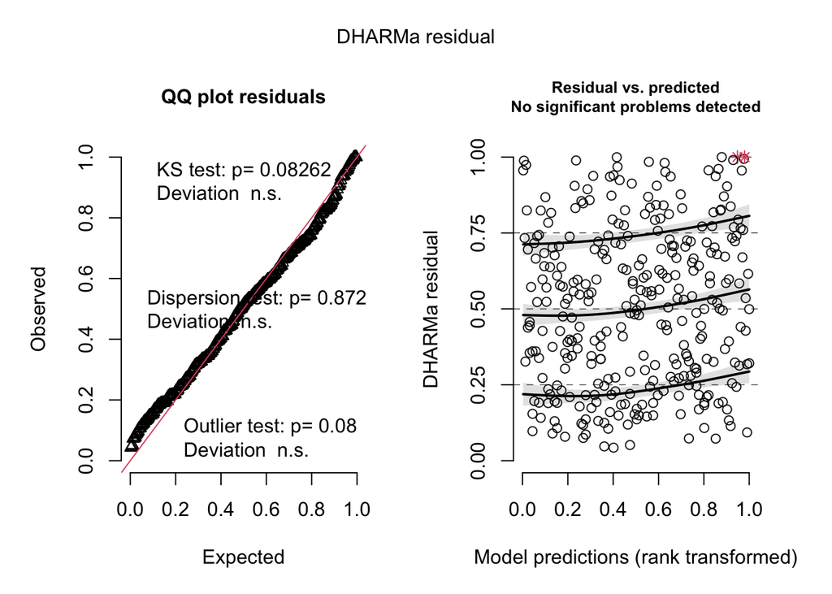

```r
plants.resid <- simulateResiduals(activityplants, n = 250)
plot(plants.resid)
```

# 5 Figures

## 5.1 Table 1

```r
table1 <- final.genus %>%
  group_by(site, year, date, round) %>%
  tally() %>%
  group_by(site, year) %>%
  tally(name = "rounds.sampled") %>%
  right_join(final.genus, by = c("site", "year"), multiple = "all") %>%
  group_by(site, year, rounds.sampled) %>%
  summarise(days.sampled = length(unique(date)))
table1
```

```
## # A tibble: 10 × 4
## # Groups:   site, year [10]
##    site             year  rounds.sampled days.sampled
##    <chr>            <chr>          <int>        <int>
##  1 Brush Creek Hill 2021              16            6
##  2 Brush Creek Hill 2022              15            6
##  3 Kebler Pass      2021              20            7
##  4 Kebler Pass      2022              18            7
##  5 Ohio Pass High   2022              19            7
##  6 Ohio Pass Low    2022              20            8
##  7 Rustlers Gulch   2021              21            7
##  8 Rustlers Gulch   2022              23            8
##  9 Stupid Falls     2021              20            7
## 10 Stupid Falls     2022              23            8
```

## 5.2 Figure 1

Relationship between round and temperature.

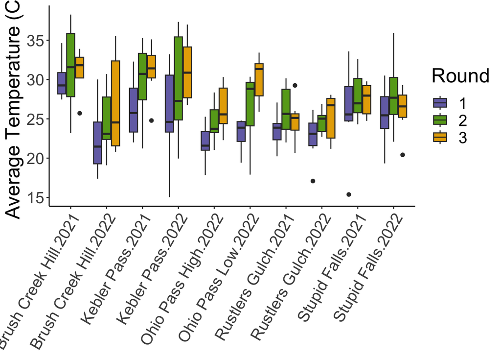

```r
fig1 <- ggplot(samptemps %>% mutate(site.year = paste(site, year, sep = ".")),
               aes(x = site.year, y = avg.temp, fill = as.factor(round))) +
  geom_boxplot() +
  scale_fill_manual(values = brewer.pal(n = 8, "Dark2")[c(3, 5, 6)]) +
  labs(y = "Average Temperature (C)",
       fill = "Round") +
  theme(axis.text.x=element_text(angle = 60, hjust = 1),
        text = element_text(size = 20),
        axis.title.x = element_blank())
fig1
```

```r
# ggsave("round-temp.png", fig1, width = 10, height = 8, units = "in")
```

## 5.3 Figures 2 & 3

General relationship between temperature and interaction occurrence.

First let’s calculate some broad-scale trends in interaction occurrence. Specifically, we will find the top 10 most frequently observed pollinator genera and the top 10 most frequently visited floral partners.

```r
top.pols <- final.genus %>%
  group_by(insect_genus) %>%
  summarise(total.int = sum(int)) %>%
  slice_max(order_by = total.int, n = 10)

top.plants <- final.genus %>%
  group_by(plant) %>%
  summarise(total.int = sum(int)) %>%
  slice_max(order_by = total.int, n = 10)

top.fams <- final.family %>%
  group_by(insect_family) %>%
  summarise(total.int = sum(int)) %>%
  slice_max(order_by = total.int, n = 10)

top.func <- final.func %>%
  group_by(gross_ID) %>%
  summarise(total.int = sum(int)) %>%
  slice_max(order_by = total.int, n = 6)

top.ints <- final.genus %>%
  filter(insect_genus %in% top.pols$insect_genus,
         plant %in% top.plants$plant) %>%
  group_by(insect_genus, plant) %>%
  summarise(total.int = sum(int)) %>%
  filter(total.int >= 5)

top.ints2 <- final.func %>%
  group_by(int.ID) %>%
  summarise(total.int = sum(int)) %>%
  slice_max(order_by = total.int, n = 50)
```

### 5.3.1 Functional Group Level

```r
# Bombus
bombus.df <- data.frame() %>%
  bind_rows(bind_cols(ggpredict(mc.func, terms = c("avg.temp [all]"), type = "fixed", condition = c(gross_ID = "Bombus", plant = "Potentilla pulcherrima")), plant = "Potentilla pulcherrima")) %>%
  bind_rows(bind_cols(ggpredict(mc.func, terms = c("avg.temp [all]"), type = "fixed", condition = c(gross_ID = "Bombus", plant = "Heliomeris multiflora")), plant = "Heliomeris multiflora")) %>%
  bind_rows(bind_cols(ggpredict(mc.func, terms = c("avg.temp [all]"), type = "fixed", condition = c(gross_ID = "Bombus", plant = "Senecio crassulus")), plant = "Senecio crassulus")) %>%
  bind_rows(bind_cols(ggpredict(mc.func, terms = c("avg.temp [all]"), type = "fixed", condition = c(gross_ID = "Bombus", plant = "Erigeron speciosus")), plant = "Erigeron speciosus"))

bombus.df[bombus.df$plant == "Potentilla pulcherrima",]$x[which.max(bombus.df[bombus.df$plant == "Potentilla pulcherrima",]$predicted)]
```

```
## [1] 30.711
```

```r
bombus.df[bombus.df$plant == "Heliomeris multiflora",]$x[which.max(bombus.df[bombus.df$plant == "Heliomeris multiflora",]$predicted)]
```

```
## [1] 38.27
```

```r
bombus.df[bombus.df$plant == "Senecio crassulus",]$x[which.max(bombus.df[bombus.df$plant == "Senecio crassulus",]$predicted)]
```

```
## [1] 34.275
```

```r
bombus.df[bombus.df$plant == "Erigeron speciosus",]$x[which.max(bombus.df[bombus.df$plant == "Erigeron speciosus",]$predicted)]
```

```
## [1] 35.276
```

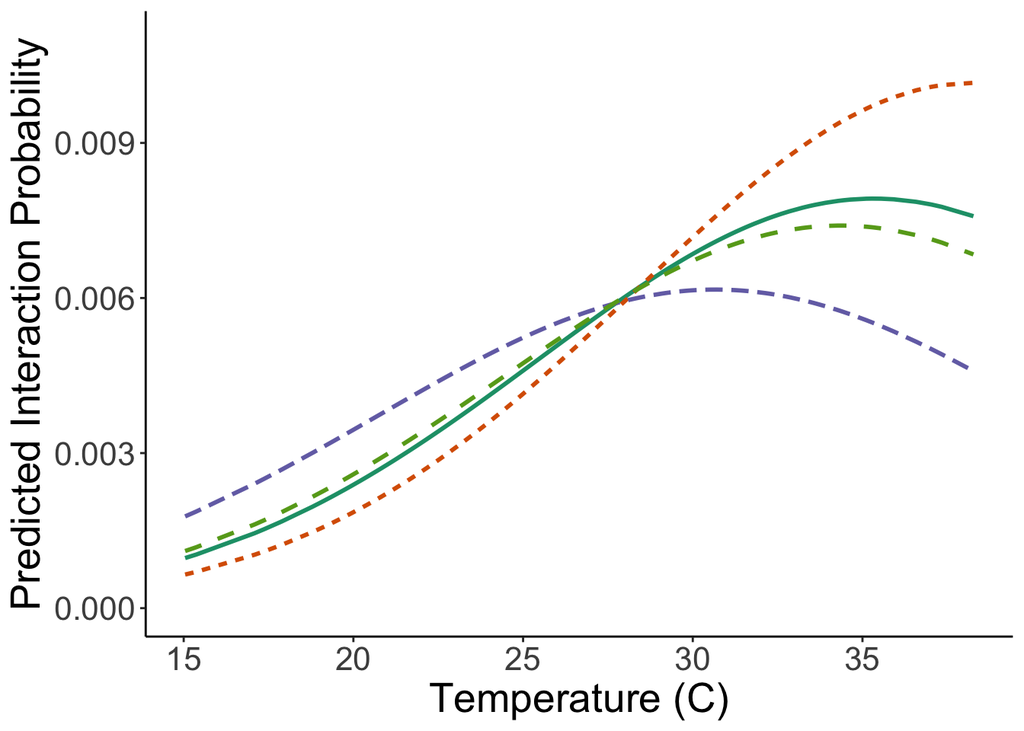

```r
bombus.plot <- ggplot(bombus.df, aes(x = x, y = predicted, color = plant, linetype = plant)) +
  geom_line(linewidth = 1) +
  scale_color_manual(values = brewer.pal(n = 5, "Dark2")[c(1, 2, 3, 5)]) +
  labs(x = "Temperature (C)",
       y = "Predicted Interaction Probability") +
  coord_cartesian(ylim = c(0, 0.011)) +
  theme(text = element_text(size = 20),
        legend.position = "none")
bombus.plot
```

```r
ggsave("bombus-predcurves.png", bombus.plot, width = 6, height = 6, units = "in")

# Syrphidae
syrphid.df <- data.frame() %>%
  bind_rows(bind_cols(ggpredict(mc.func, terms = c("avg.temp [all]"), type = "fixed", condition = c(gross_ID = "Syrphidae", plant = "Potentilla pulcherrima")), plant = "Potentilla pulcherrima")) %>%
  bind_rows(bind_cols(ggpredict(mc.func, terms = c("avg.temp [all]"), type = "fixed", condition = c(gross_ID = "Syrphidae", plant = "Heliomeris multiflora")), plant = "Heliomeris multiflora")) %>%
  bind_rows(bind_cols(ggpredict(mc.func, terms = c("avg.temp [all]"), type = "fixed", condition = c(gross_ID = "Syrphidae", plant = "Senecio crassulus")), plant = "Senecio crassulus")) %>%
  bind_rows(bind_cols(ggpredict(mc.func, terms = c("avg.temp [all]"), type = "fixed", condition = c(gross_ID = "Syrphidae", plant = "Erigeron speciosus")), plant = "Erigeron speciosus")) %>%
  bind_rows(bind_cols(ggpredict(mc.func, terms = c("avg.temp [all]"), type = "fixed", condition = c(gross_ID = "Syrphidae", plant = "Pseudocymopterus montanus")), plant = "Pseudocymopterus montanus"))

syrphid.df[syrphid.df$plant == "Potentilla pulcherrima",]$x[which.max(syrphid.df[syrphid.df$plant == "Potentilla pulcherrima",]$predicted)]
```

```
## [1] 28.308
```

```r
syrphid.df[syrphid.df$plant == "Heliomeris multiflora",]$x[which.max(syrphid.df[syrphid.df$plant == "Heliomeris multiflora",]$predicted)]
```

```
## [1] 35.918
```

```r
syrphid.df[syrphid.df$plant == "Senecio crassulus",]$x[which.max(syrphid.df[syrphid.df$plant == "Senecio crassulus",]$predicted)]
```

```
## [1] 31.829
```

```r
syrphid.df[syrphid.df$plant == "Erigeron speciosus",]$x[which.max(syrphid.df[syrphid.df$plant == "Erigeron speciosus",]$predicted)]
```

```
## [1] 32.84
```

```r
syrphid.df[syrphid.df$plant == "Pseudocymopterus montanus",]$x[which.max(syrphid.df[syrphid.df$plant == "Pseudocymopterus montanus",]$predicted)]
```

```
## [1] 26.732
```

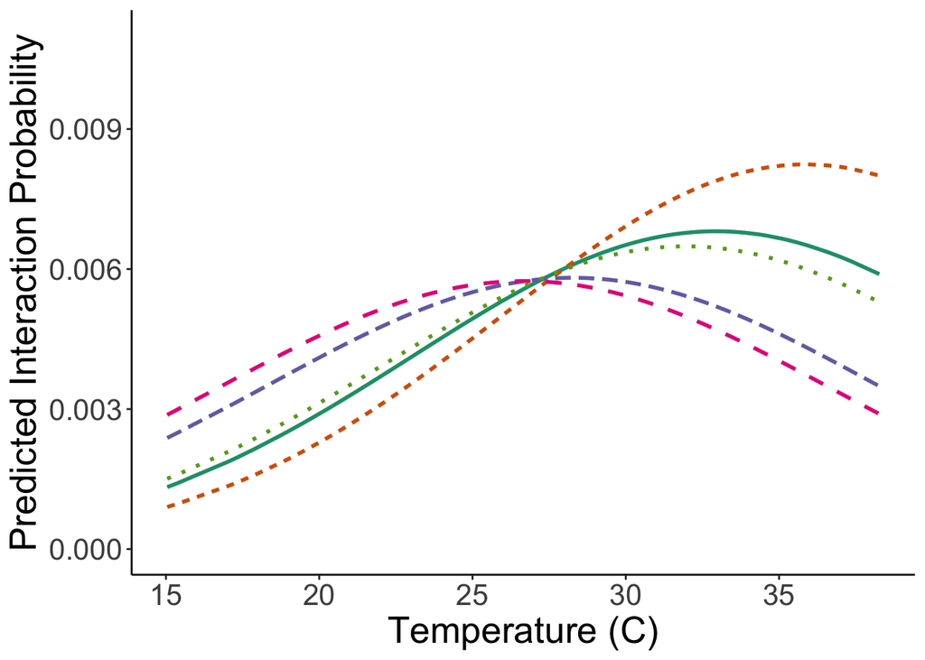

```r
syrphid.plot <- ggplot(syrphid.df, aes(x = x, y = predicted, color = plant, linetype = plant)) +
  geom_line(linewidth = 1) +
  scale_color_brewer(palette = "Dark2") +
  labs(x = "Temperature (C)",
       y = "Predicted Interaction Probability") +
  coord_cartesian(ylim = c(0, 0.011)) +
  theme(text = element_text(size = 20),
        legend.position = "none")
syrphid.plot
```

```r
ggsave("syrphid-predcurves.png", syrphid.plot, width = 6, height = 6, units = "in")

# SBSB
sbsb.df <- data.frame() %>%
  bind_rows(bind_cols(ggpredict(mc.func, terms = c("avg.temp [all]"), type = "fixed", condition = c(gross_ID = "Small black solitary bee", plant = "Potentilla pulcherrima")), plant = "Potentilla pulcherrima")) %>%
  bind_rows(bind_cols(ggpredict(mc.func, terms = c("avg.temp [all]"), type = "fixed", condition = c(gross_ID = "Small black solitary bee", plant = "Heliomeris multiflora")), plant = "Heliomeris multiflora")) %>%
  bind_rows(bind_cols(ggpredict(mc.func, terms = c("avg.temp [all]"), type = "fixed", condition = c(gross_ID = "Small black solitary bee", plant = "Senecio crassulus")), plant = "Senecio crassulus")) %>%
  bind_rows(bind_cols(ggpredict(mc.func, terms = c("avg.temp [all]"), type = "fixed", condition = c(gross_ID = "Small black solitary bee", plant = "Erigeron speciosus")), plant = "Erigeron speciosus")) %>%
  bind_rows(bind_cols(ggpredict(mc.func, terms = c("avg.temp [all]"), type = "fixed", condition = c(gross_ID = "Small black solitary bee", plant = "Pseudocymopterus montanus")), plant = "Pseudocymopterus montanus"))

sbsb.df[sbsb.df$plant == "Potentilla pulcherrima",]$x[which.max(sbsb.df[sbsb.df$plant == "Potentilla pulcherrima",]$predicted)]
```

```
## [1] 20.235
```

```r
sbsb.df[sbsb.df$plant == "Heliomeris multiflora",]$x[which.max(sbsb.df[sbsb.df$plant == "Heliomeris multiflora",]$predicted)]
```

```
## [1] 27.814
```

```r
sbsb.df[sbsb.df$plant == "Senecio crassulus",]$x[which.max(sbsb.df[sbsb.df$plant == "Senecio crassulus",]$predicted)]
```

```
## [1] 23.919
```

```r
sbsb.df[sbsb.df$plant == "Erigeron speciosus",]$x[which.max(sbsb.df[sbsb.df$plant == "Erigeron speciosus",]$predicted)]
```

```
## [1] 24.933
```

```r
sbsb.df[sbsb.df$plant == "Pseudocymopterus montanus",]$x[which.max(sbsb.df[sbsb.df$plant == "Pseudocymopterus montanus",]$predicted)]
```

```
## [1] 18.806
```

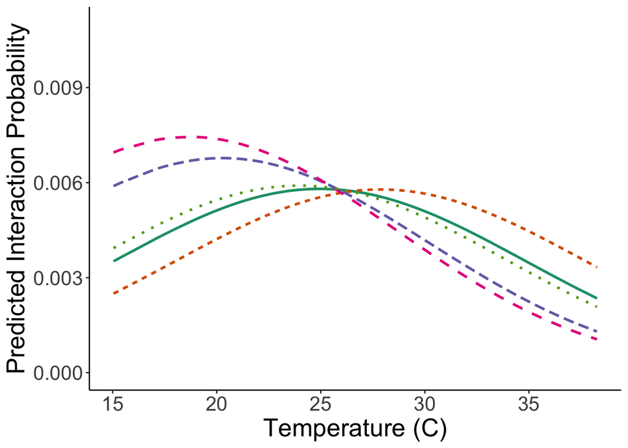

```r
sbsb.plot <- ggplot(sbsb.df, aes(x = x, y = predicted, color = plant, linetype = plant)) +
  geom_line(linewidth = 1) +
  scale_color_brewer(palette = "Dark2") +
  labs(x = "Temperature (C)",
       y = "Predicted Interaction Probability") +
  coord_cartesian(ylim = c(0, 0.011)) +
  theme(text = element_text(size = 20),
        legend.position = "none")
sbsb.plot
```

```r
ggsave("sbsb-predcurves.png", sbsb.plot, width = 6, height = 6, units = "in")

# Other Fly
fly.df <- data.frame() %>%
  bind_rows(bind_cols(ggpredict(mc.func, terms = c("avg.temp [all]"), type = "fixed", condition = c(gross_ID = "Other fly", plant = "Potentilla pulcherrima")), plant = "Potentilla pulcherrima")) %>%
  bind_rows(bind_cols(ggpredict(mc.func, terms = c("avg.temp [all]"), type = "fixed", condition = c(gross_ID = "Other fly", plant = "Heliomeris multiflora")), plant = "Heliomeris multiflora")) %>%
  bind_rows(bind_cols(ggpredict(mc.func, terms = c("avg.temp [all]"), type = "fixed", condition = c(gross_ID = "Other fly", plant = "Senecio crassulus")), plant = "Senecio crassulus")) %>%
  bind_rows(bind_cols(ggpredict(mc.func, terms = c("avg.temp [all]"), type = "fixed", condition = c(gross_ID = "Other fly", plant = "Erigeron speciosus")), plant = "Erigeron speciosus")) %>%
  bind_rows(bind_cols(ggpredict(mc.func, terms = c("avg.temp [all]"), type = "fixed", condition = c(gross_ID = "Other fly", plant = "Pseudocymopterus montanus")), plant = "Pseudocymopterus montanus"))

fly.df[fly.df$plant == "Potentilla pulcherrima",]$x[which.max(fly.df[fly.df$plant == "Potentilla pulcherrima",]$predicted)]
```

```
## [1] 21.191
```

```r
fly.df[fly.df$plant == "Heliomeris multiflora",]$x[which.max(fly.df[fly.df$plant == "Heliomeris multiflora",]$predicted)]
```

```
## [1] 28.731
```

```r
fly.df[fly.df$plant == "Senecio crassulus",]$x[which.max(fly.df[fly.df$plant == "Senecio crassulus",]$predicted)]
```

```
## [1] 24.887
```

```r
fly.df[fly.df$plant == "Erigeron speciosus",]$x[which.max(fly.df[fly.df$plant == "Erigeron speciosus",]$predicted)]
```

```
## [1] 25.902
```

```r
fly.df[fly.df$plant == "Pseudocymopterus montanus",]$x[which.max(fly.df[fly.df$plant == "Pseudocymopterus montanus",]$predicted)]
```

```
## [1] 19.758
```

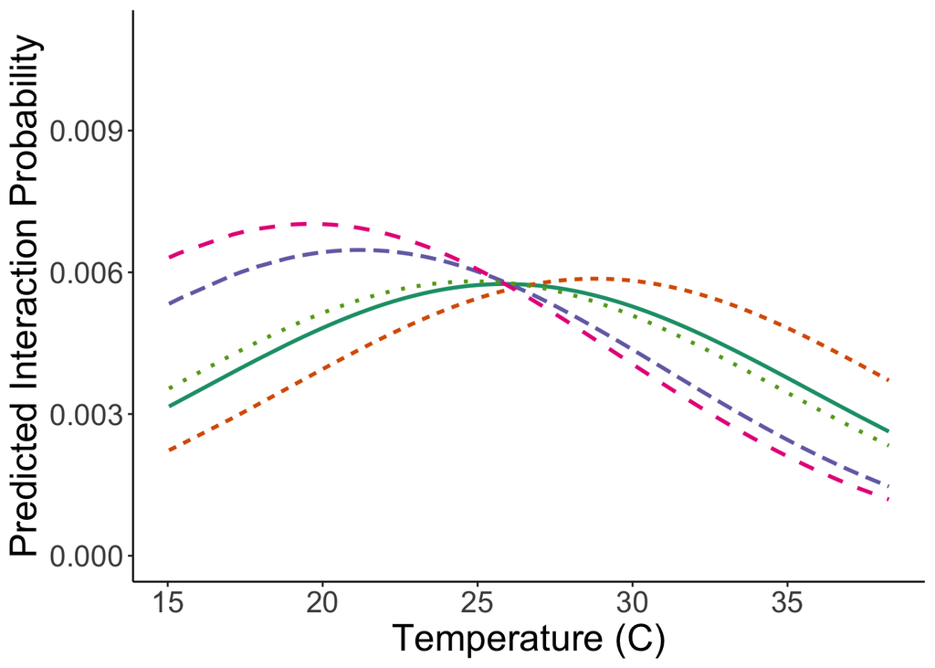

```r
fly.plot <- ggplot(fly.df, aes(x = x, y = predicted, color = plant, linetype = plant)) +
  geom_line(linewidth = 1) +
  scale_color_brewer(palette = "Dark2") +
  labs(x = "Temperature (C)",
       y = "Predicted Interaction Probability") +
  coord_cartesian(ylim = c(0, 0.011)) +
  theme(text = element_text(size = 20),
        legend.position = "none")
fly.plot
```

```r
ggsave("fly-predcurves.png", fly.plot, width = 6, height = 6, units = "in")

# Beetles
beetles.df <- data.frame() %>%
  bind_rows(bind_cols(ggpredict(mc.func, terms = c("avg.temp [all]"), type = "fixed", condition = c(gross_ID = "Beetles", plant = "Potentilla pulcherrima")), plant = "Potentilla pulcherrima")) %>%
  bind_rows(bind_cols(ggpredict(mc.func, terms = c("avg.temp [all]"), type = "fixed", condition = c(gross_ID = "Beetles", plant = "Senecio crassulus")), plant = "Senecio crassulus")) %>%
  bind_rows(bind_cols(ggpredict(mc.func, terms = c("avg.temp [all]"), type = "fixed", condition = c(gross_ID = "Beetles", plant = "Erigeron speciosus")), plant = "Erigeron speciosus")) %>%
  bind_rows(bind_cols(ggpredict(mc.func, terms = c("avg.temp [all]"), type = "fixed", condition = c(gross_ID = "Beetles", plant = "Pseudocymopterus montanus")), plant = "Pseudocymopterus montanus"))

beetles.df[beetles.df$plant == "Potentilla pulcherrima",]$x[which.max(beetles.df[beetles.df$plant == "Potentilla pulcherrima",]$predicted)]
```

```
## [1] 24.015
```

```r
beetles.df[beetles.df$plant == "Senecio crassulus",]$x[which.max(beetles.df[beetles.df$plant == "Senecio crassulus",]$predicted)]
```

```
## [1] 27.616
```

```r
beetles.df[beetles.df$plant == "Erigeron speciosus",]$x[which.max(beetles.df[beetles.df$plant == "Erigeron speciosus",]$predicted)]
```

```
## [1] 28.707
```

```r
beetles.df[beetles.df$plant == "Pseudocymopterus montanus",]$x[which.max(beetles.df[beetles.df$plant == "Pseudocymopterus montanus",]$predicted)]
```

```
## [1] 22.525
```

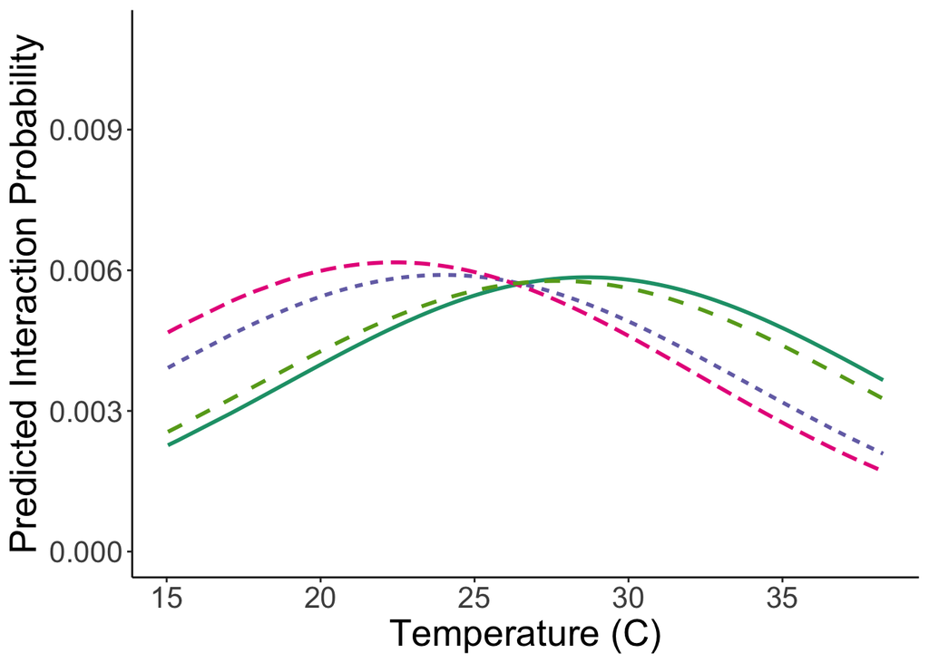

```r
beetles.plot <- ggplot(beetles.df, aes(x = x, y = predicted, color = plant, linetype = plant)) +
  geom_line(linewidth = 1) +
  scale_color_manual(values = brewer.pal(n = 5, "Dark2")[c(1, 3, 4, 5)]) +
  labs(x = "Temperature (C)",
       y = "Predicted Interaction Probability") +
  coord_cartesian(ylim = c(0, 0.011)) +
  theme(text = element_text(size = 20),
        legend.position = "none")
beetles.plot
```

```r
ggsave("beetles-predcurves.png", beetles.plot, width = 6, height = 6, units = "in")

# Hemipteran
hemip.df <- data.frame() %>%
  bind_rows(bind_cols(ggpredict(mc.func, terms = c("avg.temp [all]"), type = "fixed", condition = c(gross_ID = "Hemipteran", plant = "Potentilla pulcherrima")), plant = "Potentilla pulcherrima")) %>%
  bind_rows(bind_cols(ggpredict(mc.func, terms = c("avg.temp [all]"), type = "fixed", condition = c(gross_ID = "Hemipteran", plant = "Heliomeris multiflora")), plant = "Heliomeris multiflora")) %>%
  bind_rows(bind_cols(ggpredict(mc.func, terms = c("avg.temp [all]"), type = "fixed", condition = c(gross_ID = "Hemipteran", plant = "Senecio crassulus")), plant = "Senecio crassulus")) %>%
  bind_rows(bind_cols(ggpredict(mc.func, terms = c("avg.temp [all]"), type = "fixed", condition = c(gross_ID = "Hemipteran", plant = "Erigeron speciosus")), plant = "Erigeron speciosus")) %>%
  bind_rows(bind_cols(ggpredict(mc.func, terms = c("avg.temp [all]"), type = "fixed", condition = c(gross_ID = "Hemipteran", plant = "Pseudocymopterus montanus")), plant = "Pseudocymopterus montanus"))

hemip.df[hemip.df$plant == "Potentilla pulcherrima",]$x[which.max(hemip.df[hemip.df$plant == "Potentilla pulcherrima",]$predicted)]
```

```
## [1] 27.469
```

```r
hemip.df[hemip.df$plant == "Heliomeris multiflora",]$x[which.max(hemip.df[hemip.df$plant == "Heliomeris multiflora",]$predicted)]
```

```
## [1] 35.115
```

```r
hemip.df[hemip.df$plant == "Senecio crassulus",]$x[which.max(hemip.df[hemip.df$plant == "Senecio crassulus",]$predicted)]
```

```
## [1] 31.273
```

```r
hemip.df[hemip.df$plant == "Erigeron speciosus",]$x[which.max(hemip.df[hemip.df$plant == "Erigeron speciosus",]$predicted)]
```

```
## [1] 32.15
```

```r
hemip.df[hemip.df$plant == "Pseudocymopterus montanus",]$x[which.max(hemip.df[hemip.df$plant == "Pseudocymopterus montanus",]$predicted)]
```

```
## [1] 25.902
```

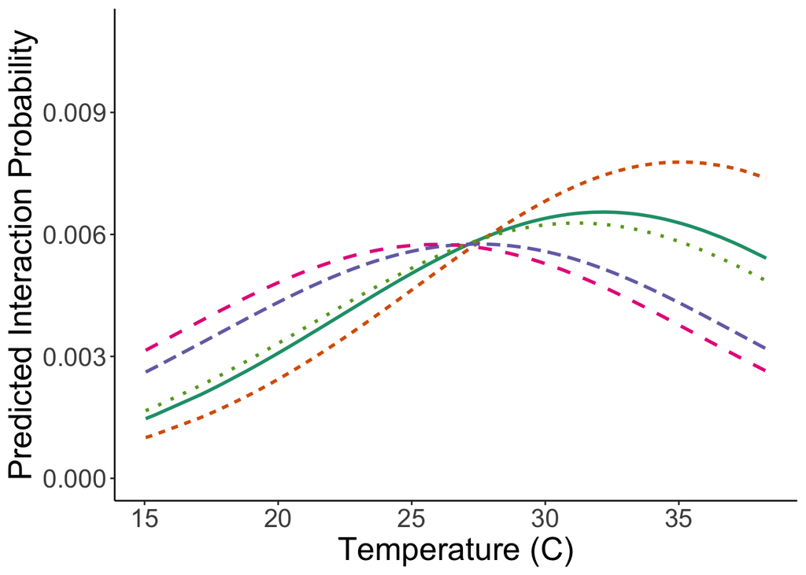

```r
hemip.plot <- ggplot(hemip.df, aes(x = x, y = predicted, color = plant, linetype = plant)) +
  geom_line(linewidth = 1) +
  scale_color_brewer(palette = "Dark2") +
  labs(x = "Temperature (C)",
       y = "Predicted Interaction Probability") +
  coord_cartesian(ylim = c(0, 0.011)) +
  theme(text = element_text(size = 20),
        legend.position = "none")
hemip.plot
```

```r
ggsave("hemip-predcurves.png", hemip.plot, width = 6, height = 6, units = "in")

legend.plot <- ggplot(hemip.df, aes(x = x, y = predicted, color = plant, linetype = plant)) +
  geom_line(linewidth = 1) +
  scale_color_brewer(palette = "Dark2") +
  labs(x = "Temperature (C)",
       y = "Predicted Interaction Probability",
       color = "Floral Partner",
       linetype = "Floral Partner") +
  coord_cartesian(ylim = c(0, 0.011)) +
  theme(text = element_text(size = 18),
        legend.position = "bottom")  +
  guides(color = guide_legend(nrow = 2),
         linetype = guide_legend(nrow = 2))
ggsave("predcurves-legend.png", legend.plot, width = 10, height = 6, units = "in")
```

## 5.4 Figure 4

```r
# SBSB
## Halictidae
halictidae.df <- data.frame() %>%
  bind_rows(bind_cols(ggpredict(mc.family, terms = c("avg.temp [all]"), type = "fixed", condition = c(insect_family = "Halictidae", plant = "Potentilla pulcherrima")), plant = "Potentilla pulcherrima"))

fam.halic <- final.family %>%
  filter(insect_family == "Halictidae") %>%
  uncount(weights = int)

halictidae.df[halictidae.df$plant == "Potentilla pulcherrima",]$x[which.max(halictidae.df[halictidae.df$plant == "Potentilla pulcherrima",]$predicted)]
```

```
## [1] 17.855
```

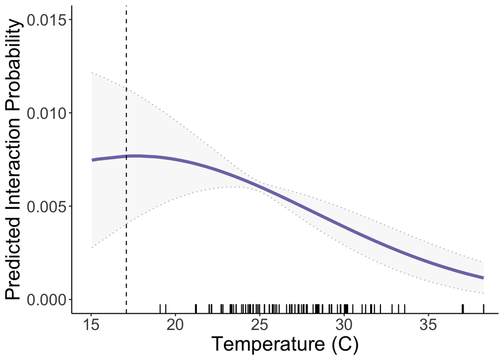

```r
mcplot.halictidae <- ggplot(halictidae.df,
                            aes(x = x)) +
  geom_line(aes(y = predicted),
            color = "#7570B3",
            linewidth = 1.5) +
  geom_ribbon(aes(ymin = conf.low, ymax = conf.high),
              fill = "grey",
              color = "grey",
              alpha = 0.1,
              linetype = "dotted") +
  geom_vline(xintercept = 17.089,
             color = "black",
             linetype = "dashed") +
  geom_rug(data = fam.halic,
           aes(x = avg.temp),
           sides = "b") +
  coord_cartesian(xlim = c(15, 38),
                  ylim = c(0, 0.015)) +
  labs(x = "Temperature (C)",
       y = "Predicted Interaction Probability",
       color = "Plant",
       fill = "Plant") +
  theme(text = element_text(size = 20),
        legend.position = "bottom")
mcplot.halictidae
```

```r
# ggsave("mcplot-halictidae.png", mcplot.halictidae, width = 6, height = 6, units = "in")

## Andrenidae
andrenidae.df <-   data.frame() %>%
  bind_rows(bind_cols(ggpredict(mc.family, terms = c("avg.temp [all]"), type = "fixed", condition = c(insect_family = "Andrenidae", plant = "Potentilla pulcherrima")), plant = "Potentilla pulcherrima"))

fam.andren <- final.family %>%
  filter(insect_family == "Andrenidae") %>%
  uncount(weights = int)

andrenidae.df[andrenidae.df$plant == "Potentilla pulcherrima",]$x[which.max(andrenidae.df[andrenidae.df$plant == "Potentilla pulcherrima",]$predicted)]
```

```
## [1] 21.713
```

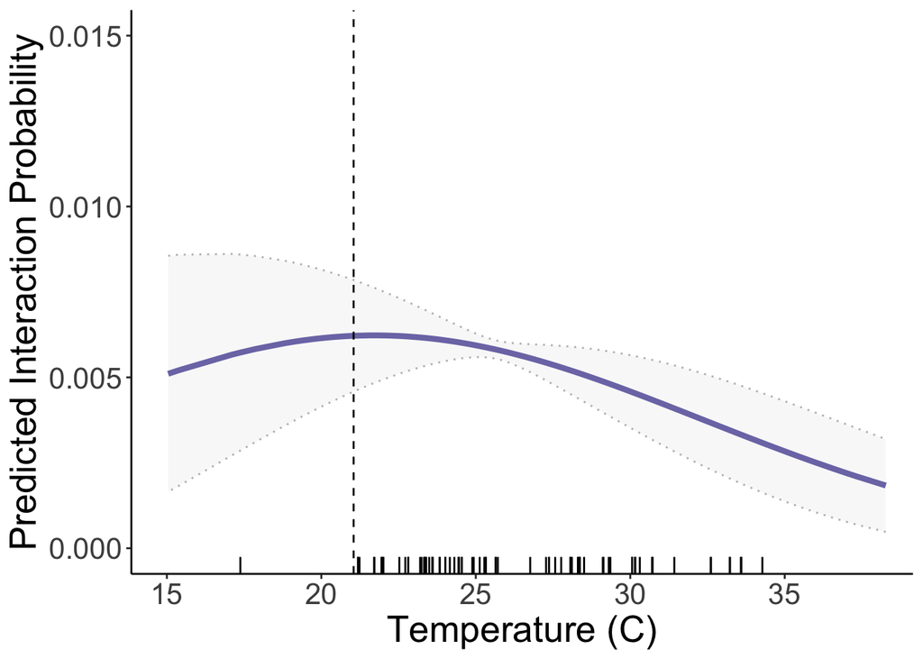

```r
mcplot.andrenidae <- ggplot(andrenidae.df, aes(x = x, )) +
  geom_line(aes(y = predicted),
            color = "#7570B3",
            linewidth = 1.5) +
  geom_ribbon(aes(ymin = conf.low, ymax = conf.high),
              fill = "grey",
              color = "grey",
              alpha = 0.1,
              linetype = "dotted") +
  geom_vline(xintercept = 21.045,
             color = "black",
             linetype = "dashed") +
  geom_rug(data = fam.andren,
           aes(x = avg.temp),
           sides = "b") +
  coord_cartesian(xlim = c(15, 38),
                  ylim = c(0, 0.015)) +
  labs(x = "Temperature (C)",
       y = "Predicted Interaction Probability") +
  theme(text = element_text(size = 20))
mcplot.andrenidae
```

```r
# ggsave("mcplot-andrenidae.png", mcplot.andrenidae, width = 6, height = 6, units = "in")
```

## 5.5 Figure 5

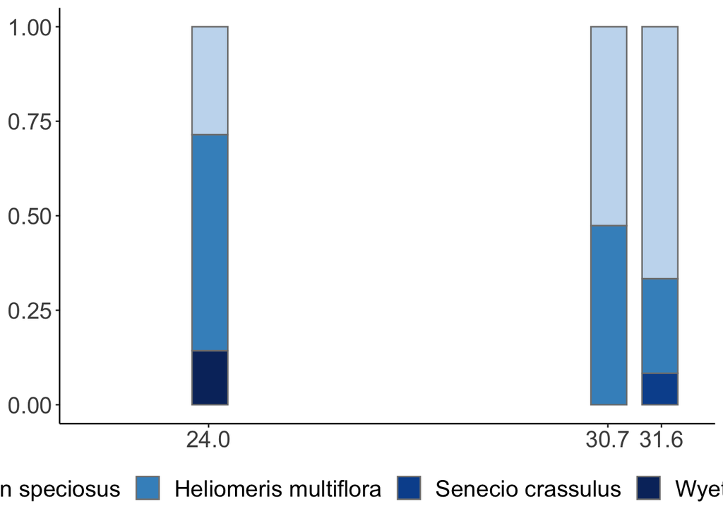

```r
# Kebler Pass, 2021-07-21
kp.072121.bombus <- final.genus %>%
  filter(insect_genus == "Bombus",
         site == "Kebler Pass",
         date == "2021-07-21") %>%
  group_by(site, date, round, insect_genus) %>%
  summarise(genus.int = sum(int)) %>%
  left_join(final.genus, by = c("site", "date", "round", "insect_genus")) %>%
  group_by(round, insect_genus, plant, avg.temp, genus.int) %>%
  summarise(int = sum(int),
            rel.int = int/genus.int) %>%
  filter(rel.int > 0)

kp.072121.plant <- plants %>%
  group_by(date, site) %>%
  summarise(total_site = sum(total_flowers)) %>%
  left_join(plants, by = c("date", "site")) %>%
  filter(site == "Kebler Pass",
         date == "2021-07-21") %>%
  group_by(site, plant) %>%
  summarise(rel.abund = total_flowers/total_site) %>%
  mutate(plant = replace(plant, plant %in% c("Agoseris glauca", "Boechera stricta", "Collomia linearis", "Linum lewisii", "Helianthella quinquenervis", "Potentilla pulcherrima"), "0ther"))

kp.072121.plot <- ggplot(kp.072121.bombus,
                      aes(x = avg.temp, y = rel.int, fill = plant)) +
  geom_bar(position = "stack",
           stat = "identity",
           col = "grey50",
           width = 0.6) +
  scale_x_continuous(breaks=c(24.0, 30.7, 31.6)) +
  scale_fill_manual(values = brewer.pal(n = 9, "Blues")[c(3, 6, 8, 9)]) +
  labs(x = "Sampling Temperature (C)",
       y = "Interaction Occurrence",
       col = "Plant") +
  theme(text = element_text(size = 20),
        legend.position = "bottom",
        axis.title = element_blank(),
        legend.title = element_blank()) +
  coord_cartesian(xlim = c(22, 32))
kp.072121.plot
```

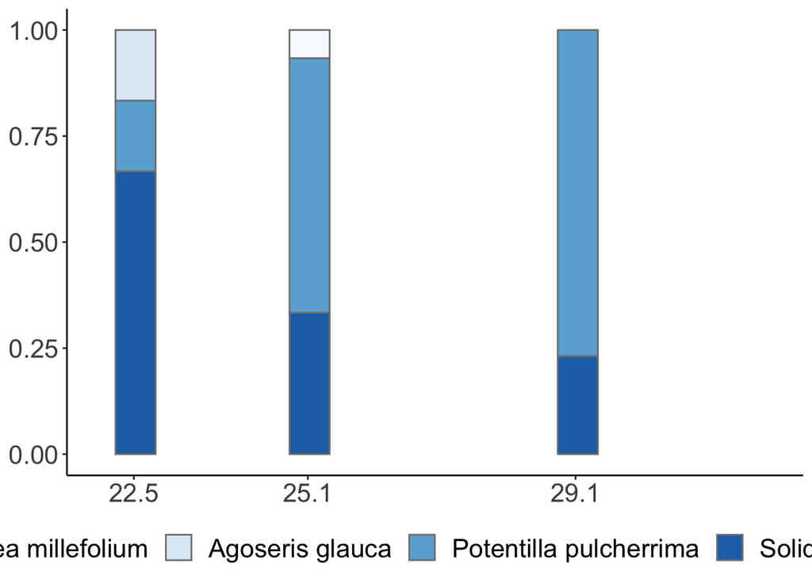

```r
kp.072121.plantplot <- ggplot(kp.072121.plant,
                              aes(x = site, y = rel.abund, fill = plant)) +
  geom_bar(position = "stack",
           stat = "identity",
           width = 1.2) +
  scale_fill_manual(labels = c("Other", sort(unique(kp.072121.plant$plant))[2:5]),
                    values = c("lightgrey", "#C6DBEF", "#4292C6", "#08519C", "#08306B"))

# Rustlers Gulch, 2021-07-27
rg.072721.bombus <- final.genus %>%
  filter(insect_genus == "Bombus",
         site == "Rustlers Gulch",
         date == "2021-07-27") %>%
  group_by(site, date, round, insect_genus) %>%
  summarise(genus.int = sum(int)) %>%
  left_join(final.genus, by = c("site", "date", "round", "insect_genus")) %>%
  group_by(round, insect_genus, plant, avg.temp, genus.int) %>%
  summarise(int = sum(int),
            rel.int = int/genus.int) %>%
  filter(rel.int > 0)

rg.072721.plant <- plants %>%
  group_by(date, site) %>%
  summarise(total_site = sum(total_flowers)) %>%
  left_join(plants, by = c("date", "site")) %>%
  filter(site == "Rustlers Gulch",
         date == "2021-07-27") %>%
  group_by(site, plant) %>%
  summarise(rel.abund = total_flowers/total_site) %>%
  mutate(plant = replace(plant, plant %in% c("Artemisia dracunculus", "Erigeron elatior", "Potentilla fruticosa", "Pseudocymopterus montanus", "Senecio bigelovii", "Valeriana edulis"), "0ther"))

rg.072721.plot <- ggplot(rg.072721.bombus %>%
                          filter(insect_genus == "Bombus"),
                      aes(x = avg.temp, y = rel.int, fill = plant)) +
  geom_bar(position = "stack",
           stat = "identity",
           col = "grey50",
           width = 0.6) +
  scale_x_continuous(breaks=c(22.5, 25.1, 29.1)) +
  scale_fill_manual(values = brewer.pal(n = 9, "Blues")[c(1, 2, 5, 7)]) +
  labs(x = "Sampling Temperature (C)",
       y = "Interaction Occurrence",
       col = "Plant") +
  theme(text = element_text(size = 20),
        legend.position = "bottom",
        axis.title = element_blank(),
        legend.title = element_blank()) +
  coord_cartesian(xlim = c(22, 32))
rg.072721.plot
```

```r
rg.072721.plantplot <- ggplot(rg.072721.plant,
                              aes(x = site, y = rel.abund, fill = plant)) +
  geom_bar(position = "stack",
           stat = "identity",
           width = 1.2) +
  scale_fill_manual(labels = c("Other", sort(unique(rg.072721.plant$plant))[2:6]),
                    values = c("lightgrey", "#F7FBFF", "#DEEBF7", "#C6DBEF", "#6BAED6", "#2171B5"))
```